# Tarea 05

Lymh Joshua Morales Chin

2/26/2021

## Procedimiento parte 1:

Para leer el archivo ‘time_series_covid19_confirmed_global.csv’ se implementaron las funciones get_file y get_dataFrame, una se encarga de leer el archivo csv y la otra de convertirlo en un dataFrame. La clase procesa_archivos recibe el direccion del file y una lista los paises que se deben leer.

```python
import pandas as pd
import numpy as np

class procesa_archivos(): ##Creamos la clase procesa archivos

    def __init__(self,file,list):  #Constructor file y la lista de paises
        self.file=file
        self.list=list

    def get_file(self):   #Con esta funcion leemos el file
        return pd.read_csv(self.file)

    def get_dataFrame(self):   #Convertimos el file en un dataFrame
        return pd.DataFrame(self.get_file())

    def delete_columns(self):   #Con esta funcion borramos las columnas 'Province/State','Lat','Long'
        covidConfirmados=self.get_dataFrame()
        return covidConfirmados.drop(['Province/State','Lat','Long'],axis=1)

    def collect_countries(self):   #Sustraemos la lista de paises
        covidConfirmados=self.get_dataFrame()
        countries=covidConfirmados.loc[:,'Country/Region']
        return countries

    def set_countryRegion_as_index(self):   #Pasamos los paises como un index
        covidConfirmados=self.delete_columns()
        new_covidConfirmados=covidConfirmados.set_index('Country/Region')
        return new_covidConfirmados

    def set_countries(self):      #Seleccionamos los paises que contiene la lista 'list'
        covidConfirmados=self.set_countryRegion_as_index()
        new_covidConfirmados=covidConfirmados.loc[self.list]
        return new_covidConfirmados

    def countries_selected(self):   #Unimos las francias ya que esta se compone de varias subAreas
        covidConfirmados=self.set_countries()
        covidConfirmados=covidConfirmados.groupby(covidConfirmados.index).agg(lambda m:sum(m))
        return covidConfirmados
```

Para imprimir el dataFrame se debe primero instanciar la clase y luego llamar a sus funciones como se muestra a continuacion:

```python
countries=['Costa Rica', 'Guatemala', 'Ecuador', 'Brazil' , 'Germany']
covidConfirmados=procesa_archivos('./time_series_covid19_confirmed_global.csv',countries)
print(covidConfirmados.get_dataFrame())
```

```
##     Province/State      Country/Region        Lat  ...  2/4/21  2/5/21  2/6/21
## 0              NaN         Afghanistan  33.939110  ...   55231   55265   55330
## 1              NaN             Albania  41.153300  ...   81993   83082   84212
## 2              NaN             Algeria  28.033900  ...  108381  108629  108629
## 3              NaN             Andorra  42.506300  ...   10137   10172   10206
## 4              NaN              Angola -11.202700  ...   19996   20030   20062
## ..             ...                 ...        ...  ...     ...     ...     ...
## 268            NaN             Vietnam  14.058324  ...    1957    1976    1985
## 269            NaN  West Bank and Gaza  31.952200  ...  161087  161559  162029
## 270            NaN               Yemen  15.552727  ...    2122    2124    2127
## 271            NaN              Zambia -13.133897  ...   59003   60427   61427
## 272            NaN            Zimbabwe -19.015438  ...   34171   34331   34487
##
## [273 rows x 386 columns]
```

El dataFrame anterior posee 386 columnas y 273 filas. Se van van a eliminar las columnas “Lat”,“Long” y “Province/State”, utilizando la funcion drop de pandas que se encarga de eliminar columnas usando la etiqueta de cada columna o fila.

```python
print(covidConfirmados.delete_columns())
```

```
##          Country/Region  1/22/20  1/23/20  ...  2/4/21  2/5/21  2/6/21
## 0           Afghanistan        0        0  ...   55231   55265   55330
## 1               Albania        0        0  ...   81993   83082   84212
## 2               Algeria        0        0  ...  108381  108629  108629
## 3               Andorra        0        0  ...   10137   10172   10206
## 4                Angola        0        0  ...   19996   20030   20062
## ..                  ...      ...      ...  ...     ...     ...     ...
## 268             Vietnam        0        2  ...    1957    1976    1985
## 269  West Bank and Gaza        0        0  ...  161087  161559  162029
## 270               Yemen        0        0  ...    2122    2124    2127
## 271              Zambia        0        0  ...   59003   60427   61427
## 272            Zimbabwe        0        0  ...   34171   34331   34487
##
## [273 rows x 383 columns]
```

Se crea una funcion llamada collect_countries para guardar como parametro la lista de paises.

```python
print(covidConfirmados.collect_countries())
```

```
## 0             Afghanistan
## 1                 Albania
## 2                 Algeria
## 3                 Andorra
## 4                  Angola
##               ...
## 268               Vietnam
## 269    West Bank and Gaza
## 270                 Yemen
## 271                Zambia
## 272              Zimbabwe
## Name: Country/Region, Length: 273, dtype: object
```

Al crear la clase procesa_archivos esta recibe una lista de paises “Costa Rica”, “Guatemala”, “Ecuador”, “Brasil” y “Germany” a seleccionar, para esto se creo una funcion llamada set_countryRegion_as_index() para colocar la lista de paises como index y set_countries() para seleccionar los paises anteriores, por tanto, el dataFrame se va a ver de la siguiente manera.

```python
print(covidConfirmados.set_countries())
```

```
##                 1/22/20  1/23/20  1/24/20  ...   2/4/21   2/5/21   2/6/21
## Country/Region                             ...
## Costa Rica            0        0        0  ...   195992   196438   196438
## Guatemala             0        0        0  ...   161665   162295   162937
## Ecuador               0        0        0  ...   253339   255412   257115
## Brazil                0        0        0  ...  9396293  9447165  9447165
## Germany               0        0        0  ...  2265536  2276371  2285003
##
## [5 rows x 382 columns]
```

## Parte 2:

Se crea una clase que toma el dataFrame anterior

```python
from parte1 import procesa_archivos
```

```
##                 1/22/20  1/23/20  1/24/20  ...   2/4/21   2/5/21   2/6/21
## Country/Region                             ...
## Brazil                0        0        0  ...  9396293  9447165  9447165
## Costa Rica            0        0        0  ...   195992   196438   196438
## Ecuador               0        0        0  ...   253339   255412   257115
## France                0        0        2  ...  3310071  3355678  3376266
## Germany               0        0        0  ...  2265536  2276371  2285003
## Guatemala             0        0        0  ...   161665   162295   162937
##
## [6 rows x 382 columns]
```

```python
from numpy import mean, std
import numpy as np
import pandas as pd
import datetime
import matplotlib.pyplot as plt
import seaborn as sns
class  analysis(procesa_archivos):

    def dataFrame(self):
       covid=self.countries_selected()  #Agarammos el dataFrame anterior
       return covid

    def arrange_data(self):  #Se arregla el dataFrame para que con las columnas como months_x y years_x
        cases_covid=self.countries_selected()
        cases_covid=cases_covid.T

        cases_covid = cases_covid.diff()   #Calcula la diferencia entre dias de cada mes
        cases_covid = cases_covid.drop(index='1/22/20')  #Se quita la columna de ceros
        months = pd.DatetimeIndex(cases_covid.index).month  #se pasa el index a formato dataTime de cada month

        dates = cases_covid.assign(month_x = months)
        years = pd.DatetimeIndex(cases_covid.index).year
        dates = dates.assign(year_x = years)

        return dates

    def statistic_measures(self):
        cases_covid=self.arrange_data()   #Se jala dates

        cases_covid_total = cases_covid.groupby(['month_x', 'year_x']).sum()  #Se suman todos los casos
        cases_covid_promedio = cases_covid.groupby(['month_x', 'year_x']).mean() #Se saca la promedio de los casos por mes
        cases_covid_media = cases_covid.groupby(['month_x', 'year_x']).median()  #Se saca la mediana de los casos por mes
        cases_covid_desviacion = cases_covid.groupby(['month_x', 'year_x']).std() #Se saca la desviacion estandar

        cases_covid_quartile1= cases_covid.groupby(['month_x', 'year_x']).quantile([0.25])  #Se calculan los cuartile
        cases_covid_quartile2= cases_covid.groupby(['month_x', 'year_x']).quantile([0.50])
        cases_covid_quartile3= cases_covid.groupby(['month_x', 'year_x']).quantile([0.75])

        return cases_covid_total, cases_covid_promedio, cases_covid_media, cases_covid_desviacion, cases_covid_quartile1,cases_covid_quartile2,cases_covid_quartile3

    def box_DataFrame(self):
        sum, prom, medi, standar, q1, q2, q3=self.statistic_measures()
        sum.boxplot(column=['Costa Rica', 'Guatemala','France', 'Ecuador', 'Brazil' , 'Germany']) #Se imprime el boxplot de los casos por mes
        plt.show()  #se muestra la grafica

    def cor_DataFrame(self):
        sum, prom, medi, standar, q1, q2, q3=self.statistic_measures()
        sns.heatmap(sum.corr(), annot=True)  #Se muestra la correlacion entre paises normalizadas
        plt.show() # se muestra la grafica
```

Parte del procedimiento consiste enordenar el dataFrame para poder agrupar por mes y por ano. Para esto se creo la funcion arrange_data. Se encarga de transponer el dataFrame y pasar el index que esta compuesto de fechas a formato dataTime, se agrupa por month y por year.

```python
countries=['Costa Rica', 'Guatemala', 'France','Ecuador', 'Brazil' , 'Germany']
confirm=analysis('./time_series_covid19_confirmed_global.csv',countries)
print(confirm.arrange_data())
```

```
## Country/Region   Brazil  Costa Rica  Ecuador  ...  Guatemala  month_x  year_x
## 1/23/20             0.0         0.0      0.0  ...        0.0        1    2020
## 1/24/20             0.0         0.0      0.0  ...        0.0        1    2020
## 1/25/20             0.0         0.0      0.0  ...        0.0        1    2020
## 1/26/20             0.0         0.0      0.0  ...        0.0        1    2020
## 1/27/20             0.0         0.0      0.0  ...        0.0        1    2020
## ...                 ...         ...      ...  ...        ...      ...     ...
## 2/2/21          54096.0       440.0    293.0  ...      667.0        2    2021
## 2/3/21          56002.0       528.0   1111.0  ...      667.0        2    2021
## 2/4/21          56873.0       455.0    949.0  ...      699.0        2    2021
## 2/5/21          50872.0       446.0   2073.0  ...      630.0        2    2021
## 2/6/21              0.0         0.0   1703.0  ...      642.0        2    2021
##
## [381 rows x 8 columns]
```

```python
sum, prom, medi, standar, q1, q2, q3=confirm.statistic_measures()
print(sum)
```

```
## Country/Region     Brazil  Costa Rica  Ecuador    France   Germany  Guatemala
## month_x year_x
## 1       2020          0.0         0.0      0.0       5.0       5.0        0.0
##         2021    1528758.0     23955.0  38316.0  578254.0  465139.0    21492.0
## 2       2020          2.0         0.0      0.0      95.0      74.0        0.0
##         2021     242434.0      3162.0   6287.0  120346.0   59344.0     3433.0
## 3       2020       5715.0       347.0   2240.0   52178.0   71729.0       38.0
## 4       2020      81470.0       372.0  22694.0  116583.0   91201.0      561.0
## 5       2020     427662.0       337.0  14164.0   22114.0   20401.0     4488.0
## 6       2020     887192.0      2403.0  17334.0   13269.0   12008.0    13009.0
## 7       2020    1260444.0     14361.0  28923.0   22995.0   14981.0    31693.0
## 8       2020    1245787.0     23467.0  28412.0   93921.0   34403.0    24285.0
## 9       2020     902663.0     34473.0  23280.0  284733.0   48111.0    17672.0
## 10      2020     724670.0     34211.0  31145.0  808471.0  238877.0    16193.0
## 11      2020     800273.0     29667.0  24493.0  862510.0  538122.0    14123.0
## 12      2020    1340095.0     29683.0  19827.0  400792.0  690608.0    15950.0
```

Luego se realizo lo mismo para calcular pero con sus respectivas funciones para calcular el promedio, la mediana, la desviacion estandar y los quartile.

```python
print("Promedio")
```

```
## Promedio
```

```python
print(prom)
```

```
## Country/Region        Brazil   Costa Rica  ...       Germany    Guatemala
## month_x year_x                             ...
## 1       2020        0.000000     0.000000  ...      0.555556     0.000000
##         2021    49314.774194   772.741935  ...  15004.483871   693.290323
## 2       2020        0.068966     0.000000  ...      2.551724     0.000000
##         2021    40405.666667   527.000000  ...   9890.666667   572.166667
## 3       2020      184.354839    11.193548  ...   2313.838710     1.225806
## 4       2020     2715.666667    12.400000  ...   3040.033333    18.700000
## 5       2020    13795.548387    10.870968  ...    658.096774   144.774194
## 6       2020    29573.066667    80.100000  ...    400.266667   433.633333
## 7       2020    40659.483871   463.258065  ...    483.258065  1022.354839
## 8       2020    40186.677419   757.000000  ...   1109.774194   783.387097
## 9       2020    30088.766667  1149.100000  ...   1603.700000   589.066667
## 10      2020    23376.451613  1103.580645  ...   7705.709677   522.354839
## 11      2020    26675.766667   988.900000  ...  17937.400000   470.766667
## 12      2020    43228.870968   957.516129  ...  22277.677419   514.516129
##
## [14 rows x 6 columns]
```

```python
print("Mediana")
```

```
## Mediana
```

```python
print(medi)
```

```
## Country/Region   Brazil  Costa Rica  Ecuador   France  Germany  Guatemala
## month_x year_x
## 1       2020        0.0         0.0      0.0      0.0      0.0        0.0
##         2021    59119.0       765.0   1008.0  20825.0  12430.0      782.0
## 2       2020        0.0         0.0      0.0      0.0      0.0        0.0
##         2021    52484.0       450.5   1030.0  21962.5   9733.5      654.5
## 3       2020       51.0         8.0     11.0   1388.0   1597.0        0.0
## 4       2020     2097.0        10.0    301.5   2550.5   2609.0       14.5
## 5       2020    13028.0         9.0    452.0    521.0    672.0      132.0
## 6       2020    30444.0        68.5    574.5    468.0    373.5      407.5
## 7       2020    41857.0       446.0    914.0    595.0    434.0      963.0
## 8       2020    45392.0       728.0    887.0   2923.0   1220.0      915.0
## 9       2020    33190.5      1271.0    917.5   9171.5   1590.5      683.0
## 10      2020    26106.0      1210.0    912.0  23002.0   6541.0      609.0
## 11      2020    26769.0      1123.5    838.5  22938.5  18594.5      611.5
## 12      2020    49863.0      1084.0    607.0  12882.0  23275.0      627.0
```

```python
print("Desviacion estandar")
```

```
## Desviacion estandar
```

```python
print(standar)
```

```
## Country/Region        Brazil  Costa Rica  ...       Germany   Guatemala
## month_x year_x                            ...
## 1       2020        0.000000    0.000000  ...      1.013794    0.000000
##         2021    19536.610733  773.412437  ...   9212.239145  422.632637
## 2       2020        0.257881    0.000000  ...      6.711324    0.000000
##         2021    23212.538083  420.428353  ...   2619.673389  218.896703
## 3       2020      249.596147   11.013384  ...   2263.703840    1.667527
## 4       2020     1754.222695    8.552475  ...   1702.343425   16.021860
## 5       2020     7007.702504    6.438126  ...    304.720348  106.110543
## 6       2020     9727.998181   48.577240  ...    227.552788  166.497278
## 7       2020    13710.512366  158.369393  ...    189.635961  656.430121
## 8       2020    13792.036619  301.665267  ...    449.144573  354.189373
## 9       2020    14619.596194  530.260336  ...    470.841664  259.946272
## 10      2020    12013.445156  493.014724  ...   5098.697299  230.619824
## 11      2020    13363.177654  692.264219  ...   7965.275420  255.012060
## 12      2020    15815.538142  800.917552  ...  10605.388566  272.666692
##
## [14 rows x 6 columns]
```

```python
print("Primer quartile")
```

```
## Primer quartile
```

```python
print(q1)
```

```
## Country/Region         Brazil  Costa Rica  ...   Germany  Guatemala
## month_x year_x                             ...
## 1       2020   0.25      0.00        0.00  ...      0.00       0.00
##         2021   0.25  28039.50        0.00  ...   9732.50     274.00
## 2       2020   0.25      0.00        0.00  ...      0.00       0.00
##         2021   0.25  31161.25      441.50  ...   7925.50     633.00
## 3       2020   0.25      5.50        1.00  ...    204.00       0.00
## 4       2020   0.25   1344.25        6.00  ...   1680.75       8.00
## 5       2020   0.25   8094.50        6.00  ...    434.00      53.50
## 6       2020   0.25  22856.00       40.25  ...    259.50     313.00
## 7       2020   0.25  27291.50      355.00  ...    343.50     752.00
## 8       2020   0.25  24610.50      583.00  ...    708.00     382.00
## 9       2020   0.25  14864.75     1094.50  ...   1318.25     316.50
## 10      2020   0.25  14609.50     1014.00  ...   3553.50     285.50
## 11      2020   0.25  14652.25      871.00  ...  13934.50     182.75
## 12      2020   0.25  25319.00        0.00  ...  14356.50     184.50
##
## [14 rows x 6 columns]
```

```python
print("Segundo quartile")
```

```
## Segundo quartile
```

```python
print(q2)
```

```
## Country/Region       Brazil  Costa Rica  Ecuador   France  Germany  Guatemala
## month_x year_x
## 1       2020   0.5      0.0         0.0      0.0      0.0      0.0        0.0
##         2021   0.5  59119.0       765.0   1008.0  20825.0  12430.0      782.0
## 2       2020   0.5      0.0         0.0      0.0      0.0      0.0        0.0
##         2021   0.5  52484.0       450.5   1030.0  21962.5   9733.5      654.5
## 3       2020   0.5     51.0         8.0     11.0   1388.0   1597.0        0.0
## 4       2020   0.5   2097.0        10.0    301.5   2550.5   2609.0       14.5
## 5       2020   0.5  13028.0         9.0    452.0    521.0    672.0      132.0
## 6       2020   0.5  30444.0        68.5    574.5    468.0    373.5      407.5
## 7       2020   0.5  41857.0       446.0    914.0    595.0    434.0      963.0
## 8       2020   0.5  45392.0       728.0    887.0   2923.0   1220.0      915.0
## 9       2020   0.5  33190.5      1271.0    917.5   9171.5   1590.5      683.0
## 10      2020   0.5  26106.0      1210.0    912.0  23002.0   6541.0      609.0
## 11      2020   0.5  26769.0      1123.5    838.5  22938.5  18594.5      611.5
## 12      2020   0.5  49863.0      1084.0    607.0  12882.0  23275.0      627.0
```

```python
print("Tercer quartile")
```

```
## Tercer quartile
```

```python
print(q3)
```

```
## Country/Region         Brazil  Costa Rica  ...   Germany  Guatemala
## month_x year_x                             ...
## 1       2020   0.75      0.00        0.00  ...      1.00        0.0
##         2021   0.75  62312.00     1120.50  ...  18713.00     1033.5
## 2       2020   0.75      0.00        0.00  ...      2.00        0.0
##         2021   0.75  55525.50      509.75  ...  12074.00      667.0
## 3       2020   0.75    323.00       19.00  ...   4260.00        2.0
## 4       2020   0.75   3646.25       19.00  ...   4020.75       27.0
## 5       2020   0.75  16821.50       14.00  ...    805.00      212.0
## 6       2020   0.75  34461.00      112.00  ...    499.00      542.0
## 7       2020   0.75  47408.50      555.00  ...    592.50     1172.0
## 8       2020   0.75  50131.00      967.50  ...   1503.50     1083.5
## 9       2020   0.75  39052.75     1394.75  ...   1854.25      800.5
## 10      2020   0.75  28576.00     1363.50  ...  11394.50      684.5
## 11      2020   0.75  35762.00     1223.50  ...  23500.25      678.0
## 12      2020   0.75  53940.50     1174.00  ...  29721.00      723.0
##
## [14 rows x 6 columns]
```

Se grafico el numero de casos por mes de cada pais usando boxplots. El procedimiento se observa en la funcion box_DataFrame.

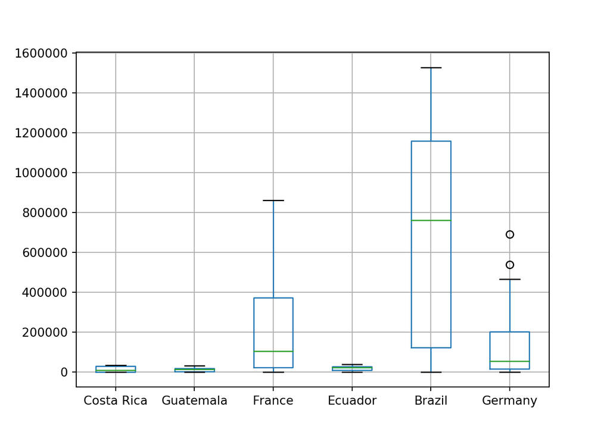

```python
confirm.box_DataFrame()
```

Y por ultimo, la correlacion entre paises se obtuve con la funcion corr() y la libreria sns.

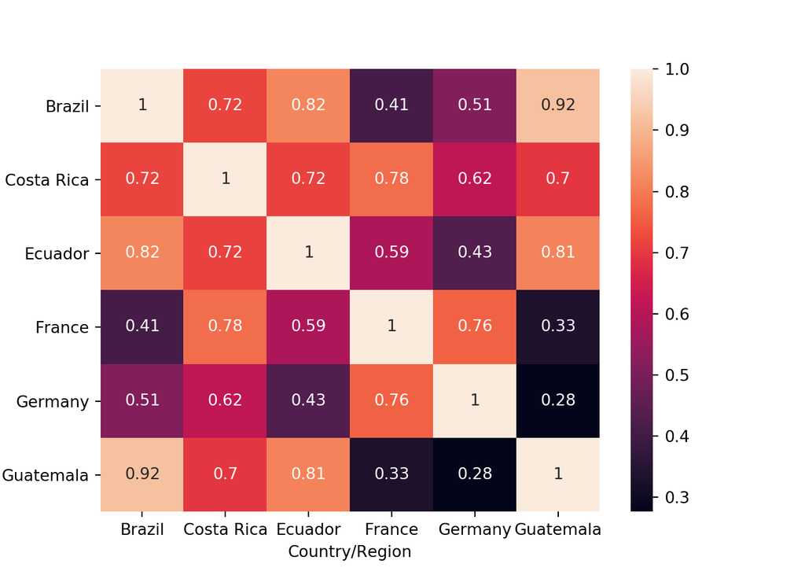

```python
confirm.cor_DataFrame()
```